# Credit Card Users Churn Prediction

## Problem Statement

### Business Context

The Thera bank recently saw a steep decline in the number of users of their credit card, credit cards are a good source of income for banks because of different kinds of fees charged by the banks like annual fees, balance transfer fees, and cash advance fees, late payment fees, foreign transaction fees, and others. Some fees are charged to every user irrespective of usage, while others are charged under specified circumstances.

Customers’ leaving credit cards services would lead bank to loss, so the bank wants to analyze the data of customers and identify the customers who will leave their credit card services and reason for same – so that bank could improve upon those areas

You as a Data scientist at Thera bank need to come up with a classification model that will help the bank improve its services so that customers do not renounce their credit cards

### Data Description

- CLIENTNUM: Client number. Unique identifier for the customer holding the account
- Attrition_Flag: Internal event (customer activity) variable - if the account is closed then "Attrited Customer" else "Existing Customer"
- Customer_Age: Age in Years
- Gender: Gender of the account holder
- Dependent_count: Number of dependents
- Education_Level: Educational Qualification of the account holder - Graduate, High School, Unknown, Uneducated, College(refers to college student), Post-Graduate, Doctorate
- Marital_Status: Marital Status of the account holder
- Income_Category: Annual Income Category of the account holder
- Card_Category: Type of Card
- Months_on_book: Period of relationship with the bank (in months)
- Total_Relationship_Count: Total no. of products held by the customer
- Months_Inactive_12_mon: No. of months inactive in the last 12 months
- Contacts_Count_12_mon: No. of Contacts in the last 12 months
- Credit_Limit: Credit Limit on the Credit Card
- Total_Revolving_Bal: Total Revolving Balance on the Credit Card
- Avg_Open_To_Buy: Open to Buy Credit Line (Average of last 12 months)
- Total_Amt_Chng_Q4_Q1: Change in Transaction Amount (Q4 over Q1)
- Total_Trans_Amt: Total Transaction Amount (Last 12 months)
- Total_Trans_Ct: Total Transaction Count (Last 12 months)
- Total_Ct_Chng_Q4_Q1: Change in Transaction Count (Q4 over Q1)
- Avg_Utilization_Ratio: Average Card Utilization Ratio

#### What Is a Revolving Balance?

- If we don't pay the balance of the revolving credit account in full every month, the unpaid portion carries over to the next month. That's called a revolving balance

##### What is the Average Open to buy?

- 'Open to Buy' means the amount left on your credit card to use. Now, this column represents the average of this value for the last 12 months.

##### What is the Average utilization Ratio?

- The Avg_Utilization_Ratio represents how much of the available credit the customer spent. This is useful for calculating credit scores.

##### Relation b/w Avg_Open_To_Buy, Credit_Limit and Avg_Utilization_Ratio:

- ( Avg_Open_To_Buy / Credit_Limit ) + Avg_Utilization_Ratio = 1

### **Please read the instructions carefully before starting the project.**

This is a commented Jupyter IPython Notebook file in which all the instructions and tasks to be performed are mentioned.

- Blanks '**___**' are provided in the notebook that needs to be filled with an appropriate code to get the correct result. With every '**___**' blank, there is a comment that briefly describes what needs to be filled in the blank space.
- Identify the task to be performed correctly, and only then proceed to write the required code.
- Fill the code wherever asked by the commented lines like "# write your code here" or "# complete the code". Running incomplete code may throw error.
- Please run the codes in a sequential manner from the beginning to avoid any unnecessary errors.
- Add the results/observations (wherever mentioned) derived from the analysis in the presentation and submit the same.

## Importing necessary libraries

```python
# Installing the libraries with the specified version.
# uncomment and run the following line if Google Colab is being used
# !pip install scikit-learn==1.2.2 seaborn==0.13.1 matplotlib==3.7.1 numpy==1.25.2 pandas==1.5.3 imbalanced-learn==0.10.1 xgboost==2.0.3 -q --user
```

```python
# Installing the libraries with the specified version.
# uncomment and run the following lines if Jupyter Notebook is being used
# !pip install scikit-learn==1.2.2 seaborn==0.13.1 matplotlib==3.7.1 numpy==1.25.2 pandas==1.5.3 imblearn==0.12.0 xgboost==2.0.3 -q --user
# !pip install --upgrade -q threadpoolctl
```

**Note**: *After running the above cell, kindly restart the notebook kernel and run all cells sequentially from the start again*.

```python
import numpy as np
import pandas as pd
import seaborn as sb
import scikitplot as skplt

# imblearn Libraries
from imblearn.over_sampling import SMOTE
from imblearn import __version__ as imbv

# scipy Libraries
from scipy.stats import norm
from scipy import __version__ as scipv

# matplotlib Libraries
import matplotlib.pyplot as plt
from matplotlib import __version__ as mpv

# plotly Libraries
import plotly.express as ex
from plotly import __version__ as pvm

# sklearn Libraries
from sklearn.pipeline import Pipeline
from sklearn.decomposition import PCA
from sklearn import __version__ as skv
from xgboost.sklearn import XGBClassifier
from sklearn.tree import DecisionTreeClassifier
from sklearn.preprocessing import StandardScaler
from sklearn.linear_model import LogisticRegression
from sklearn.ensemble import RandomForestClassifier
from sklearn.model_selection import train_test_split, GridSearchCV
from sklearn.metrics import make_scorer, recall_score, confusion_matrix

# Library Versions
print('Using version %s of scipy' % scipv)
print('Using version %s of pandas' % pd.__version__)
print('Using version %s of numpy' % np.__version__)
print('Using version %s of plotly' % pvm)
print('Using version %s of imblearn' % imbv)
print('Using version %s of sklearn' % skv)
print('Using version %s of seaborn' % sb.__version__)
print('Using version %s of matplotlib' % mpv)
```

```
Using version 1.11.1 of scipy
Using version 1.5.3 of pandas
Using version 1.25.2 of numpy
Using version 5.9.0 of plotly
Using version 0.10.1 of imblearn
Using version 1.2.2 of sklearn
Using version 0.13.1 of seaborn
Using version 3.7.1 of matplotlib
```

```python
from imblearn.over_sampling import SMOTE
```

```python
import seaborn as sns
```

```python
from sklearn.preprocessing import LabelEncoder, StandardScaler, MinMaxScaler
```

```python
from sklearn.feature_selection import SelectKBest, chi2, f_classif
```

```python
from sklearn.model_selection import train_test_split, GridSearchCV, KFold, cross_val_score
```

```python
from sklearn.metrics  import confusion_matrix, classification_report, accuracy_score, f1_score, roc_auc_score, roc_curve
from statsmodels.stats.outliers_influence import variance_inflation_factor
import imblearn
```

```python
from sklearn import tree
from sklearn.tree import DecisionTreeClassifier
```

```python
from sklearn.ensemble import RandomForestClassifier, GradientBoostingClassifier
from sklearn import metrics
from sklearn.metrics  import confusion_matrix, classification_report, accuracy_score, f1_score, roc_auc_score, roc_curve
from statsmodels.stats.outliers_influence import variance_inflation_factor
import imblearn
```

```python
from sklearn.neighbors import KNeighborsClassifier
```

## Loading the dataset

```python
df = pd.read_csv('BankChurners_JA.csv')
```

```python
df.drop(['CLIENTNUM'], axis = 1, inplace = True)
```

## Data Overview

- Observations
- Sanity checks

```python
df.head()
```

|  | Attrition_Flag | Customer_Age | Gender | Dependent_count | Education_Level | Marital_Status | Income_Category | Card_Category | Months_on_book | Total_Relationship_Count | Months_Inactive_12_mon | Contacts_Count_12_mon | Credit_Limit | Total_Revolving_Bal | Avg_Open_To_Buy | Total_Amt_Chng_Q4_Q1 | Total_Trans_Amt | Total_Trans_Ct | Total_Ct_Chng_Q4_Q1 | Avg_Utilization_Ratio |
| --- | --- | --- | --- | --- | --- | --- | --- | --- | --- | --- | --- | --- | --- | --- | --- | --- | --- | --- | --- | --- |
| 0 | Existing Customer | 45 | M | 3 | High School | Married | $60K - $80K | Blue | 39 | 5 | 1 | 3 | 12691.0 | 777 | 11914.0 | 1.335 | 1144 | 42 | 1.625 | 0.061 |
| 1 | Existing Customer | 49 | F | 5 | Graduate | Single | Less than $40K | Blue | 44 | 6 | 1 | 2 | 8256.0 | 864 | 7392.0 | 1.541 | 1291 | 33 | 3.714 | 0.105 |
| 2 | Existing Customer | 51 | M | 3 | Graduate | Married | $80K - $120K | Blue | 36 | 4 | 1 | 0 | 3418.0 | 0 | 3418.0 | 2.594 | 1887 | 20 | 2.333 | 0.000 |
| 3 | Existing Customer | 40 | F | 4 | High School | NaN | Less than $40K | Blue | 34 | 3 | 4 | 1 | 3313.0 | 2517 | 796.0 | 1.405 | 1171 | 20 | 2.333 | 0.760 |
| 4 | Existing Customer | 40 | M | 3 | Uneducated | Married | $60K - $80K | Blue | 21 | 5 | 1 | 0 | 4716.0 | 0 | 4716.0 | 2.175 | 816 | 28 | 2.500 | 0.000 |

```python
print(df.shape)
```

```
(10127, 20)
```

```python
df.describe()
```

|  | Customer_Age | Dependent_count | Months_on_book | Total_Relationship_Count | Months_Inactive_12_mon | Contacts_Count_12_mon | Credit_Limit | Total_Revolving_Bal | Avg_Open_To_Buy | Total_Amt_Chng_Q4_Q1 | Total_Trans_Amt | Total_Trans_Ct | Total_Ct_Chng_Q4_Q1 | Avg_Utilization_Ratio |
| --- | --- | --- | --- | --- | --- | --- | --- | --- | --- | --- | --- | --- | --- | --- |
| count | 10127.000000 | 10127.000000 | 10127.000000 | 10127.000000 | 10127.000000 | 10127.000000 | 10127.000000 | 10127.000000 | 10127.000000 | 10127.000000 | 10127.000000 | 10127.000000 | 10127.000000 | 10127.000000 |
| mean | 46.325960 | 2.346203 | 35.928409 | 3.812580 | 2.341167 | 2.455317 | 8631.953698 | 1162.814061 | 7469.139637 | 0.759941 | 4404.086304 | 64.858695 | 0.712222 | 0.274894 |
| std | 8.016814 | 1.298908 | 7.986416 | 1.554408 | 1.010622 | 1.106225 | 9088.776650 | 814.987335 | 9090.685324 | 0.219207 | 3397.129254 | 23.472570 | 0.238086 | 0.275691 |
| min | 26.000000 | 0.000000 | 13.000000 | 1.000000 | 0.000000 | 0.000000 | 1438.300000 | 0.000000 | 3.000000 | 0.000000 | 510.000000 | 10.000000 | 0.000000 | 0.000000 |
| 25% | 41.000000 | 1.000000 | 31.000000 | 3.000000 | 2.000000 | 2.000000 | 2555.000000 | 359.000000 | 1324.500000 | 0.631000 | 2155.500000 | 45.000000 | 0.582000 | 0.023000 |
| 50% | 46.000000 | 2.000000 | 36.000000 | 4.000000 | 2.000000 | 2.000000 | 4549.000000 | 1276.000000 | 3474.000000 | 0.736000 | 3899.000000 | 67.000000 | 0.702000 | 0.176000 |
| 75% | 52.000000 | 3.000000 | 40.000000 | 5.000000 | 3.000000 | 3.000000 | 11067.500000 | 1784.000000 | 9859.000000 | 0.859000 | 4741.000000 | 81.000000 | 0.818000 | 0.503000 |
| max | 73.000000 | 5.000000 | 56.000000 | 6.000000 | 6.000000 | 6.000000 | 34516.000000 | 2517.000000 | 34516.000000 | 3.397000 | 18484.000000 | 139.000000 | 3.714000 | 0.999000 |

```python
df.info()
```

```
<class 'pandas.core.frame.DataFrame'>
RangeIndex: 10127 entries, 0 to 10126
Data columns (total 20 columns):
 #   Column                    Non-Null Count  Dtype
---  ------                    --------------  -----
 0   Attrition_Flag            10127 non-null  object
 1   Customer_Age              10127 non-null  int64
 2   Gender                    10127 non-null  object
 3   Dependent_count           10127 non-null  int64
 4   Education_Level           8608 non-null   object
 5   Marital_Status            9378 non-null   object
 6   Income_Category           10127 non-null  object
 7   Card_Category             10127 non-null  object
 8   Months_on_book            10127 non-null  int64
 9   Total_Relationship_Count  10127 non-null  int64
 10  Months_Inactive_12_mon    10127 non-null  int64
 11  Contacts_Count_12_mon     10127 non-null  int64
 12  Credit_Limit              10127 non-null  float64
 13  Total_Revolving_Bal       10127 non-null  int64
 14  Avg_Open_To_Buy           10127 non-null  float64
 15  Total_Amt_Chng_Q4_Q1      10127 non-null  float64
 16  Total_Trans_Amt           10127 non-null  int64
 17  Total_Trans_Ct            10127 non-null  int64
 18  Total_Ct_Chng_Q4_Q1       10127 non-null  float64
 19  Avg_Utilization_Ratio     10127 non-null  float64
dtypes: float64(5), int64(9), object(6)
memory usage: 1.5+ MB
```

```python
df = df.fillna(0)
```

```python
df.isnull().sum()
```

```
Attrition_Flag              0
Customer_Age                0
Gender                      0
Dependent_count             0
Education_Level             0
Marital_Status              0
Income_Category             0
Card_Category               0
Months_on_book              0
Total_Relationship_Count    0
Months_Inactive_12_mon      0
Contacts_Count_12_mon       0
Credit_Limit                0
Total_Revolving_Bal         0
Avg_Open_To_Buy             0
Total_Amt_Chng_Q4_Q1        0
Total_Trans_Amt             0
Total_Trans_Ct              0
Total_Ct_Chng_Q4_Q1         0
Avg_Utilization_Ratio       0
dtype: int64
```

```python
df.duplicated().sum()
```

```
0
```

```python
df.columns
```

```
Index(['Attrition_Flag', 'Customer_Age', 'Gender', 'Dependent_count',
       'Education_Level', 'Marital_Status', 'Income_Category', 'Card_Category',
       'Months_on_book', 'Total_Relationship_Count', 'Months_Inactive_12_mon',
       'Contacts_Count_12_mon', 'Credit_Limit', 'Total_Revolving_Bal',
       'Avg_Open_To_Buy', 'Total_Amt_Chng_Q4_Q1', 'Total_Trans_Amt',
       'Total_Trans_Ct', 'Total_Ct_Chng_Q4_Q1', 'Avg_Utilization_Ratio'],
      dtype='object')
```

```python
df = df.rename(columns = {'Attrition_Flag': 'att',
                          'Customer_Age': 'age', 'Gender': 'gender', 'Dependent_count': 'dep',
                          'Education_Level': 'edu', 'Marital_Status': 'marital', 'Income_Category': 'income',
                          'Card_Category': 'card','Months_on_book': 'book_months',
                          'Total_Relationship_Count': 'rel', 'Months_Inactive_12_mon': 'inactive',
                          'Contacts_Count_12_mon': 'contacts', 'Credit_Limit': 'credit_limit',
                          'Total_Revolving_Bal': 'rev_bal', 'Avg_Open_To_Buy': 'buy',
                          'Total_Amt_Chng_Q4_Q1': 'amt_change', 'Total_Trans_Amt': 'trans_amt',
                          'Total_Trans_Ct': 'trans_count', 'Total_Ct_Chng_Q4_Q1': 'trans_count_change',
                          'Avg_Utilization_Ratio': 'util'})
df.columns
```

```
Index(['att', 'age', 'gender', 'dep', 'edu', 'marital', 'income', 'card',
       'book_months', 'rel', 'inactive', 'contacts', 'credit_limit', 'rev_bal',
       'buy', 'amt_change', 'trans_amt', 'trans_count', 'trans_count_change',
       'util'],
      dtype='object')
```

```python
catcols= []
numcols = []
for column in df.columns:
    if df[column].dtype == 'object':
        catcols.append(column)
    elif df[column].dtype in ['int64', 'float64']:
        numcols.append(column)

print(catcols)
print("Number of categorical columns: ", len(catcols))
print()
print(numcols)
print("Number of categorical columns: ", len(numcols))
```

```
['att', 'gender', 'edu', 'marital', 'income', 'card']
Number of categorical columns:  6

['age', 'dep', 'book_months', 'rel', 'inactive', 'contacts', 'credit_limit', 'rev_bal', 'buy', 'amt_change', 'trans_amt', 'trans_count', 'trans_count_change', 'util']
Number of categorical columns:  14
```

Categorical Variables Nominal: Gender, Marital, att ---- will need one hot encoding Ordinal: Education, Income, Card

```python
df
```

|  | att | age | gender | dep | edu | marital | income | card | book_months | rel | inactive | contacts | credit_limit | rev_bal | buy | amt_change | trans_amt | trans_count | trans_count_change | util |
| --- | --- | --- | --- | --- | --- | --- | --- | --- | --- | --- | --- | --- | --- | --- | --- | --- | --- | --- | --- | --- |
| 0 | Existing Customer | 45 | M | 3 | High School | Married | $60K - $80K | Blue | 39 | 5 | 1 | 3 | 12691.0 | 777 | 11914.0 | 1.335 | 1144 | 42 | 1.625 | 0.061 |
| 1 | Existing Customer | 49 | F | 5 | Graduate | Single | Less than $40K | Blue | 44 | 6 | 1 | 2 | 8256.0 | 864 | 7392.0 | 1.541 | 1291 | 33 | 3.714 | 0.105 |
| 2 | Existing Customer | 51 | M | 3 | Graduate | Married | $80K - $120K | Blue | 36 | 4 | 1 | 0 | 3418.0 | 0 | 3418.0 | 2.594 | 1887 | 20 | 2.333 | 0.000 |
| 3 | Existing Customer | 40 | F | 4 | High School | 0 | Less than $40K | Blue | 34 | 3 | 4 | 1 | 3313.0 | 2517 | 796.0 | 1.405 | 1171 | 20 | 2.333 | 0.760 |
| 4 | Existing Customer | 40 | M | 3 | Uneducated | Married | $60K - $80K | Blue | 21 | 5 | 1 | 0 | 4716.0 | 0 | 4716.0 | 2.175 | 816 | 28 | 2.500 | 0.000 |
| ... | ... | ... | ... | ... | ... | ... | ... | ... | ... | ... | ... | ... | ... | ... | ... | ... | ... | ... | ... | ... |
| 10122 | Existing Customer | 50 | M | 2 | Graduate | Single | $40K - $60K | Blue | 40 | 3 | 2 | 3 | 4003.0 | 1851 | 2152.0 | 0.703 | 15476 | 117 | 0.857 | 0.462 |
| 10123 | Attrited Customer | 41 | M | 2 | 0 | Divorced | $40K - $60K | Blue | 25 | 4 | 2 | 3 | 4277.0 | 2186 | 2091.0 | 0.804 | 8764 | 69 | 0.683 | 0.511 |
| 10124 | Attrited Customer | 44 | F | 1 | High School | Married | Less than $40K | Blue | 36 | 5 | 3 | 4 | 5409.0 | 0 | 5409.0 | 0.819 | 10291 | 60 | 0.818 | 0.000 |
| 10125 | Attrited Customer | 30 | M | 2 | Graduate | 0 | $40K - $60K | Blue | 36 | 4 | 3 | 3 | 5281.0 | 0 | 5281.0 | 0.535 | 8395 | 62 | 0.722 | 0.000 |
| 10126 | Attrited Customer | 43 | F | 2 | Graduate | Married | Less than $40K | Silver | 25 | 6 | 2 | 4 | 10388.0 | 1961 | 8427.0 | 0.703 | 10294 | 61 | 0.649 | 0.189 |

10127 rows × 20 columns

## Exploratory Data Analysis (EDA)

- EDA is an important part of any project involving data.
- It is important to investigate and understand the data better before building a model with it.
- A few questions have been mentioned below which will help you approach the analysis in the right manner and generate insights from the data.
- A thorough analysis of the data, in addition to the questions mentioned below, should be done.

**Questions**:

1. How is the total transaction amount distributed?
2. What is the distribution of the level of education of customers?
3. What is the distribution of the level of income of customers?
4. How does the change in transaction amount between Q4 and Q1 (`total_ct_change_Q4_Q1`) vary by the customer's account status (`Attrition_Flag`)?
5. How does the number of months a customer was inactive in the last 12 months (`Months_Inactive_12_mon`) vary by the customer's account status (`Attrition_Flag`)?
6. What are the attributes that have a strong correlation with each other?

#### The below functions need to be defined to carry out the Exploratory Data Analysis.

```
                    att
Existing Customer  8500
Attrited Customer  1627
---------
   gender
F    5358
M    4769
---------
                edu
Graduate       3128
High School    2013
0              1519
Uneducated     1487
College        1013
Post-Graduate   516
Doctorate       451
---------
          marital
Married      4687
Single       3943
0             749
Divorced      748
---------
                income
Less than $40K    3561
$40K - $60K       1790
$80K - $120K      1535
$60K - $80K       1402
abc               1112
$120K +            727
---------
          card
Blue      9436
Silver     555
Gold       116
Platinum    20
```

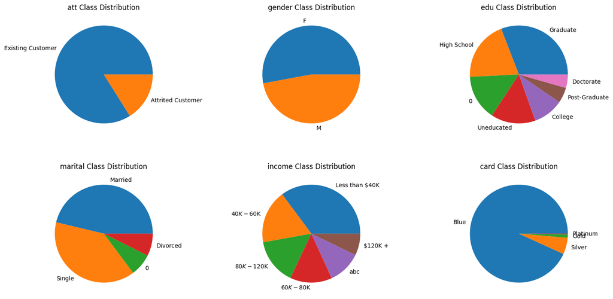

```python
c = 1
plt.subplots(figsize=(17, 17))
plt.subplots_adjust(left=0.1,
                    bottom=0.1,
                    right=0.9,
                    top=0.5,
                    wspace=0.4,
                    hspace = 0.3)
for column in catcols:
    counts = df[column].value_counts()
    print(pd.DataFrame(counts))
    plt.subplot(2, 3, c)
    plt.pie(df[column].value_counts(), labels = counts.index)
    plt.title(f'{column} Class Distribution')
    print("---------")
    c = c+1

plt.show()
```

```python
for column in catcols:
    print(df.groupby(column).att.value_counts())
    print('------------------------------------------')

# we note that we have only 20 records for platinum card owners
```

```
att                att
Attrited Customer  Attrited Customer    1627
Existing Customer  Existing Customer    8500
Name: att, dtype: int64
------------------------------------------
gender  att
F       Existing Customer    4428
        Attrited Customer     930
M       Existing Customer    4072
        Attrited Customer     697
Name: att, dtype: int64
------------------------------------------
edu            att
0              Existing Customer    1263
               Attrited Customer     256
College        Existing Customer     859
               Attrited Customer     154
Doctorate      Existing Customer     356
               Attrited Customer      95
Graduate       Existing Customer    2641
               Attrited Customer     487
High School    Existing Customer    1707
               Attrited Customer     306
Post-Graduate  Existing Customer     424
               Attrited Customer      92
Uneducated     Existing Customer    1250
               Attrited Customer     237
Name: att, dtype: int64
------------------------------------------
marital   att
0         Existing Customer     620
          Attrited Customer     129
Divorced  Existing Customer     627
          Attrited Customer     121
Married   Existing Customer    3978
          Attrited Customer     709
Single    Existing Customer    3275
          Attrited Customer     668
Name: att, dtype: int64
------------------------------------------
```

[output cut: 11 more lines]

```
abc             Existing Customer     925
                Attrited Customer     187
Name: att, dtype: int64
------------------------------------------
card      att
Blue      Existing Customer    7917
          Attrited Customer    1519
Gold      Existing Customer      95
          Attrited Customer      21
Platinum  Existing Customer      15
          Attrited Customer       5
Silver    Existing Customer     473
          Attrited Customer      82
Name: att, dtype: int64
------------------------------------------
```

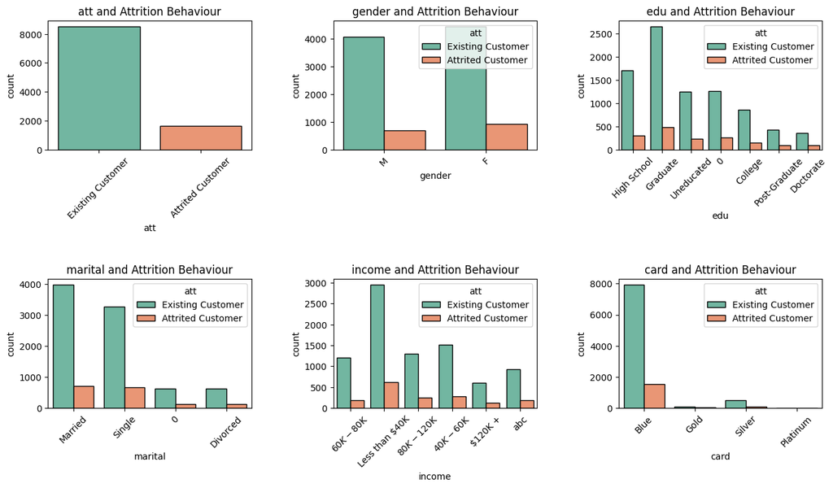

```python
c = 1
plt.subplots(figsize=(15, 15))
plt.subplots_adjust(left = 0.1,
                    bottom = 0.1,
                    right = 0.9,
                    top = 0.5,
                    wspace = 0.4,
                    hspace = 1.0) # space between rows
for column in catcols:
    plt.subplot(2, 3, c)
    figure = sns.countplot(x = df[column], hue = df['att'], edgecolor = 'black', palette = "Set2")
    figure.set_xticklabels(labels = figure.get_xticklabels(), rotation=45)
    c = c+1
    plt.title(f'{column} and Attrition Behaviour')

plt.show()
```

```python
# Convert specified columns to string type
columns_to_encode = ['att', 'gender', 'marital']
df[columns_to_encode] = df[columns_to_encode].astype(str)

# Dictionary to store LabelEncoders
le = {}

# Encode specified columns
for column in columns_to_encode:
    le[f'le_{column}'] = LabelEncoder()
    df[column] = le[f'le_{column}'].fit_transform(df[column])

# Print the dictionary containing all the fitted encoders
print(le)

# Show the head of the DataFrame to verify the transformations
print(df.head())
```

```
{'le_att': LabelEncoder(), 'le_gender': LabelEncoder(), 'le_marital': LabelEncoder()}
   att  age  gender  dep          edu  marital          income  card  \
0    1   45       1    3  High School        2     $60K - $80K  Blue
1    1   49       0    5     Graduate        3  Less than $40K  Blue
2    1   51       1    3     Graduate        2    $80K - $120K  Blue
3    1   40       0    4  High School        0  Less than $40K  Blue
4    1   40       1    3   Uneducated        2     $60K - $80K  Blue

   book_months  rel  inactive  contacts  credit_limit  rev_bal      buy  \
0           39    5         1         3       12691.0      777  11914.0
1           44    6         1         2        8256.0      864   7392.0
2           36    4         1         0        3418.0        0   3418.0
3           34    3         4         1        3313.0     2517    796.0
4           21    5         1         0        4716.0        0   4716.0

   amt_change  trans_amt  trans_count  trans_count_change   util
0       1.335       1144           42               1.625  0.061
1       1.541       1291           33               3.714  0.105
2       2.594       1887           20               2.333  0.000
3       1.405       1171           20               2.333  0.760
4       2.175        816           28               2.500  0.000
```

```python
catcols
```

```
['att', 'gender', 'edu', 'marital', 'income', 'card']
```

```python
df.card.value_counts()
```

```
Blue        9436
Silver       555
Gold         116
Platinum      20
Name: card, dtype: int64
```

```python
# labels for ordinal features (could not use LabelEncoder since these variables are ordinal)
edu_l = []
income_l = []
card_l = []

for i, data in df.iterrows():
    if data['edu'] == 'Unknown':
        edu_l.append(0)
    if data['edu'] == 'Uneducated':
        edu_l.append(1)
    if data['edu'] == 'High School':
        edu_l.append(2)
    if data['edu'] == 'College':
        edu_l.append(3)
    if data['edu'] == 'Graduate':
        edu_l.append(4)
    if data['edu'] == 'Post-Graduate':
        edu_l.append(5)
    if data['edu'] == 'Doctorate':
        edu_l.append(6)

    if data['income'] == 'Unknown':
        income_l.append(0)
    if data['income'] == 'Less than $40K':
        income_l.append(1)
    if data['income'] == '$40K - $60K':
        income_l.append(2)
    if data['income'] == '$60K - $80K':
        income_l.append(3)
    if data['income'] == '$80K - $120K':
        income_l.append(4)
    if data['income'] == '$120K +':
        income_l.append(5)

    if data['card'] == 'Blue':
        card_l.append(0)
    if data['card'] == 'Silver':
        card_l.append(1)
    if data['card'] == 'Gold':
        card_l.append(2)
    if data['card'] == 'Platinum':
        card_l.append(3)
```

```python
# Define mappings for each column
edu_mapping = {
    'Unknown': 0,
    'Uneducated': 1,
    'High School': 2,
    'College': 3,
    'Graduate': 4,
    'Post-Graduate': 5,
    'Doctorate': 6
}

income_mapping = {
    'Unknown': 0,
    'Less than $40K': 1,
    '$40K - $60K': 2,
    '$60K - $80K': 3,
    '$80K - $120K': 4,
    '$120K +': 5
}

card_mapping = {
    'Blue': 0,
    'Silver': 1,
    'Gold': 2,
    'Platinum': 3
}
```

```python
# Apply mappings to DataFrame and create new columns
df['edu_l'] = df['edu'].map(edu_mapping)
df['income_l'] = df['income'].map(income_mapping)
df['card_l'] = df['card'].map(card_mapping)
```

```python
# Display columns to verify
print(df.columns)
```

```
Index(['att', 'age', 'gender', 'dep', 'edu', 'marital', 'income', 'card',
       'book_months', 'rel', 'inactive', 'contacts', 'credit_limit', 'rev_bal',
       'buy', 'amt_change', 'trans_amt', 'trans_count', 'trans_count_change',
       'util', 'edu_l', 'income_l', 'card_l'],
      dtype='object')
```

```python
catcols
```

```
['att', 'gender', 'edu', 'marital', 'income', 'card']
```

```python
df
```

|  | att | age | gender | dep | edu | marital | income | card | book_months | rel | ... | rev_bal | buy | amt_change | trans_amt | trans_count | trans_count_change | util | edu_l | income_l | card_l |
| --- | --- | --- | --- | --- | --- | --- | --- | --- | --- | --- | --- | --- | --- | --- | --- | --- | --- | --- | --- | --- | --- |
| 0 | 1 | 45 | 1 | 3 | High School | 2 | $60K - $80K | Blue | 39 | 5 | ... | 777 | 11914.0 | 1.335 | 1144 | 42 | 1.625 | 0.061 | 2.0 | 3.0 | 0 |
| 1 | 1 | 49 | 0 | 5 | Graduate | 3 | Less than $40K | Blue | 44 | 6 | ... | 864 | 7392.0 | 1.541 | 1291 | 33 | 3.714 | 0.105 | 4.0 | 1.0 | 0 |
| 2 | 1 | 51 | 1 | 3 | Graduate | 2 | $80K - $120K | Blue | 36 | 4 | ... | 0 | 3418.0 | 2.594 | 1887 | 20 | 2.333 | 0.000 | 4.0 | 4.0 | 0 |
| 3 | 1 | 40 | 0 | 4 | High School | 0 | Less than $40K | Blue | 34 | 3 | ... | 2517 | 796.0 | 1.405 | 1171 | 20 | 2.333 | 0.760 | 2.0 | 1.0 | 0 |
| 4 | 1 | 40 | 1 | 3 | Uneducated | 2 | $60K - $80K | Blue | 21 | 5 | ... | 0 | 4716.0 | 2.175 | 816 | 28 | 2.500 | 0.000 | 1.0 | 3.0 | 0 |
| ... | ... | ... | ... | ... | ... | ... | ... | ... | ... | ... | ... | ... | ... | ... | ... | ... | ... | ... | ... | ... | ... |
| 10122 | 1 | 50 | 1 | 2 | Graduate | 3 | $40K - $60K | Blue | 40 | 3 | ... | 1851 | 2152.0 | 0.703 | 15476 | 117 | 0.857 | 0.462 | 4.0 | 2.0 | 0 |
| 10123 | 0 | 41 | 1 | 2 | 0 | 1 | $40K - $60K | Blue | 25 | 4 | ... | 2186 | 2091.0 | 0.804 | 8764 | 69 | 0.683 | 0.511 | NaN | 2.0 | 0 |
| 10124 | 0 | 44 | 0 | 1 | High School | 2 | Less than $40K | Blue | 36 | 5 | ... | 0 | 5409.0 | 0.819 | 10291 | 60 | 0.818 | 0.000 | 2.0 | 1.0 | 0 |
| 10125 | 0 | 30 | 1 | 2 | Graduate | 0 | $40K - $60K | Blue | 36 | 4 | ... | 0 | 5281.0 | 0.535 | 8395 | 62 | 0.722 | 0.000 | 4.0 | 2.0 | 0 |
| 10126 | 0 | 43 | 0 | 2 | Graduate | 2 | Less than $40K | Silver | 25 | 6 | ... | 1961 | 8427.0 | 0.703 | 10294 | 61 | 0.649 | 0.189 | 4.0 | 1.0 | 1 |

10127 rows × 23 columns

```python
df.card.value_counts()
```

```
Blue        9436
Silver       555
Gold         116
Platinum      20
Name: card, dtype: int64
```

```python
for column in catcols:
    print(df[column].value_counts())
    print(df[f'{column}_l'].value_counts())
    print("---------------------------")
```

```
1    8500
0    1627
Name: att, dtype: int64
```

[output not shown]

```python
df.to_csv('df1.csv', index = False)
```

Numerical Variables

```python
# Computing variances
for column in numcols:
    print(f'{column} variance: ', df[column].var())
```

```
age variance:  64.26930723247591
dep variance:  1.6871628988519742
book_months variance:  63.7828458100154
rel variance:  2.416183811827244
inactive variance:  1.0213576342059132
contacts variance:  1.2237340661998037
credit_limit variance:  82605860.99764086
rev_bal variance:  664204.356594701
buy variance:  82640559.6541551
amt_change variance:  0.04805160767656245
trans_amt variance:  11540487.165373318
trans_count variance:  550.9615634942085
trans_count_change variance:  0.05668498688619787
util variance:  0.07600578621854333
```

```python
df[numcols].describe()
```

|  | age | dep | book_months | rel | inactive | contacts | credit_limit | rev_bal | buy | amt_change | trans_amt | trans_count | trans_count_change | util |
| --- | --- | --- | --- | --- | --- | --- | --- | --- | --- | --- | --- | --- | --- | --- |
| count | 10127.000000 | 10127.000000 | 10127.000000 | 10127.000000 | 10127.000000 | 10127.000000 | 10127.000000 | 10127.000000 | 10127.000000 | 10127.000000 | 10127.000000 | 10127.000000 | 10127.000000 | 10127.000000 |
| mean | 46.325960 | 2.346203 | 35.928409 | 3.812580 | 2.341167 | 2.455317 | 8631.953698 | 1162.814061 | 7469.139637 | 0.759941 | 4404.086304 | 64.858695 | 0.712222 | 0.274894 |
| std | 8.016814 | 1.298908 | 7.986416 | 1.554408 | 1.010622 | 1.106225 | 9088.776650 | 814.987335 | 9090.685324 | 0.219207 | 3397.129254 | 23.472570 | 0.238086 | 0.275691 |
| min | 26.000000 | 0.000000 | 13.000000 | 1.000000 | 0.000000 | 0.000000 | 1438.300000 | 0.000000 | 3.000000 | 0.000000 | 510.000000 | 10.000000 | 0.000000 | 0.000000 |
| 25% | 41.000000 | 1.000000 | 31.000000 | 3.000000 | 2.000000 | 2.000000 | 2555.000000 | 359.000000 | 1324.500000 | 0.631000 | 2155.500000 | 45.000000 | 0.582000 | 0.023000 |
| 50% | 46.000000 | 2.000000 | 36.000000 | 4.000000 | 2.000000 | 2.000000 | 4549.000000 | 1276.000000 | 3474.000000 | 0.736000 | 3899.000000 | 67.000000 | 0.702000 | 0.176000 |
| 75% | 52.000000 | 3.000000 | 40.000000 | 5.000000 | 3.000000 | 3.000000 | 11067.500000 | 1784.000000 | 9859.000000 | 0.859000 | 4741.000000 | 81.000000 | 0.818000 | 0.503000 |
| max | 73.000000 | 5.000000 | 56.000000 | 6.000000 | 6.000000 | 6.000000 | 34516.000000 | 2517.000000 | 34516.000000 | 3.397000 | 18484.000000 | 139.000000 | 3.714000 | 0.999000 |

Detecting and treating outliers

```python
def outlier(column):

    # distribution
    sns.histplot(df[column])
    plt.show()

    # boxplot
    sns.boxplot(df[column])
    plt.show()

    print('max: ', df[column].max())
    print('min: ', df[column].min())

    print('Mean: ', df[column].mean())
    print()

    print('IQR STRATEGY ------------')
    Q1 = df[column].quantile(0.25)
    Q3 = df[column].quantile(0.75)
    IQR = Q3 - Q1

    r_whisker = Q3 + 1.5*IQR
    l_whisker = Q1 - 1.5 * IQR
    outsIQR = df[(df[column] > r_whisker) | (df[column] < l_whisker)]

    print('Q1: ', Q1)
    print('Q2 (median): ', df[column].median())
    print('Q3: ', Q3)

    print('Left whisker: ', l_whisker)
    print('Right whisker: ', r_whisker)

    # Quantile Strategy
    print()
    print('QUANTILE STRATEGY ------------')
    max_val = df[column].quantile(0.95)
    min_val = df[column].quantile(0.05)

    outsQ = df[(df[column] < min_val) | (df[column] > max_val)]

    print('95th percentile: ', max_val)
    print('5th percentile: ', min_val)

    ###########
    print( )
    print(f'(IQR Strategy) NUMBER OF OUTLIERS DETECTED IN THE {column} COLUMN: {len(outsIQR)}')
    print(f"(Quantile Strategy) NUMBER OF OUTLIERS DETECTED IN {column} COLUMN:", outsQ.shape[0])
```

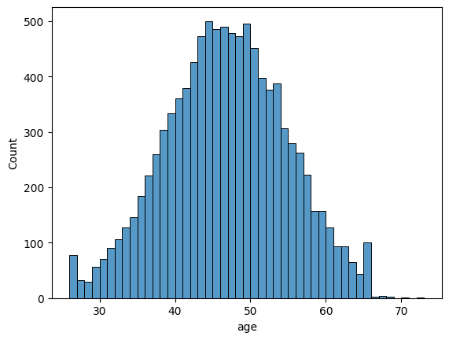

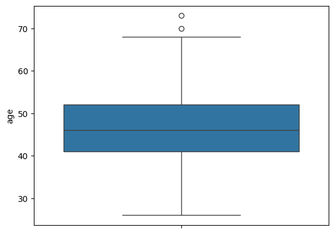

```
max:  73
min:  26
Mean:  46.32596030413745

IQR STRATEGY ------------
Q1:  41.0
Q2 (median):  46.0
Q3:  52.0
Left whisker:  24.5
Right whisker:  68.5

QUANTILE STRATEGY ------------
95th percentile:  60.0
5th percentile:  33.0

(IQR Strategy) NUMBER OF OUTLIERS DETECTED IN THE age COLUMN: 2
(Quantile Strategy) NUMBER OF OUTLIERS DETECTED IN age COLUMN: 867
```

```python
outlier('age')
```

```python
# dealing with outliers: since 70 and 73 are not too different from the right whisker, we equate them
for i, data in df.iterrows():
    if data.age > 68.5:
        df.at[i, 'age'] = 68.5
```

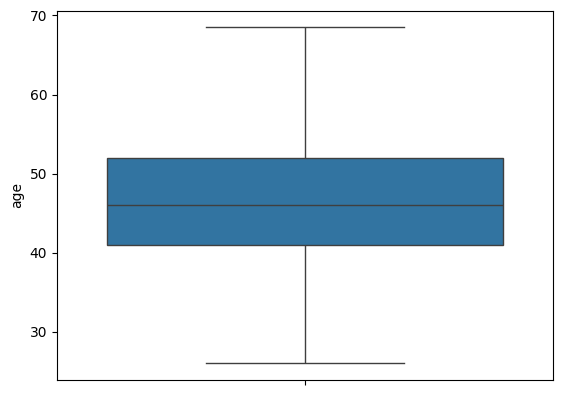

```python
sns.boxplot(df.age) # all clean
```

dep: number of people dependent on the customer

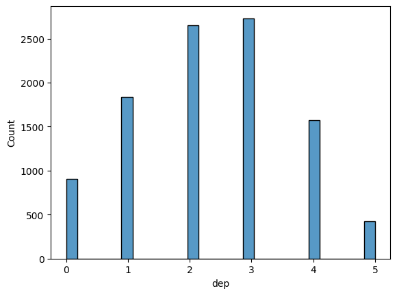

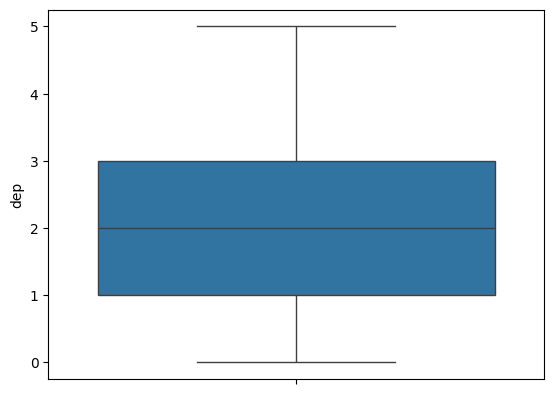

```
max:  5
min:  0
Mean:  2.3462032191172115

IQR STRATEGY ------------
Q1:  1.0
Q2 (median):  2.0
Q3:  3.0
Left whisker:  -2.0
Right whisker:  6.0

QUANTILE STRATEGY ------------
95th percentile:  4.0
5th percentile:  0.0

(IQR Strategy) NUMBER OF OUTLIERS DETECTED IN THE dep COLUMN: 0
(Quantile Strategy) NUMBER OF OUTLIERS DETECTED IN dep COLUMN: 424
```

```python
outlier('dep')
```

book_months: time on books in months